# Child survival for mothers: mortality change and related measures

Ivan Williams and Diego Alburez-Gutierrez

07 August 2019

## Introduction

Kin count estimation has a long and distinguished pedigree in mathematical demography, starting with the work of Lotka (1931) on modelling orphanhood in theoretical populations across demographic regimes. To the best of our knowledge, Brass (1953) first proposed an equation akin to Eq. to estimate child survival over age. The notion of estimating the expected number of living daughters in a stable population was generalized by Goodman, Keyfitz, and Pullum (1974) for other kin relations (granddaughters, cousins, etc.). The “counting method” approach was further popularized in Keyfitz and Caswell (2005), where the net reproduction rate $R_0$ was limited to $a$ or to the (not complete) ratio between generations (multiplying and dividing by the mother generation $B$). Bongaarts (1987) used a similar approach to estimate descendants in his ‘Family Status Model’ and, more recently, Wrycza and Baudisch (2012) has used formal techniques to describe the effect of different kind of changes in mortality by age.

The question of child survival, particularly the survival of daughters for mothers, sits at the very center of demographic theory. This is evidenced by the omnipresence of the ‘net reproductive rate’ in accounts of human and non-human populations. Historical demographers draw liberally on assumptions about kin availability and individual’s exposure to offspring mortality to explain fertility decisions, especially around the demographic transition. These assumptions are often untested given the data sparsity (Livi Bacci 1997; Volk and Atkinson 2013). Economic theories of fertility that consider children as ‘investment’ for old-age support also rely on notions of child survival (Preston and others 1978).

Child survival - and it’s counterpart, child death - gain new significance in the wake of the fertility transition. Depressed fertility means that fewer children are tasked with providing key emotional, social, and financial transfers to aging parents for ever increasing periods of time. With increasing periods of generational overlap, individuals find themselves ‘sandwiched’ between aging parents and young children requiring their simultaneous attention and care (Daatland, Veenstra, and Lima 2010). In the context of global population aging, elderly parents without access to formal social security and pension systems are particularly reliant on these transfers to make ends meet (Smith-Greenaway and Trinitapoli 2020).  
Losing an only child may become a more common experience in the context of global fertility decline, something particularly worrying for parents suddenly rendered childless. Given the known psychological, health, and social consequences of child loss for bereaved parents and families (Hendrickson 2009; Lee et al. 2014), it is surprising that the demographic processes that shape parental bereavement remain very poorly understood.

How can we characterize the timing of offspring mortality as experienced by a mother from a formal demographic perspective? How do changing mortality rates affect the availability of offspring over age for mothers, if fertility remains constant? In this paper, we uncover formal relationships to answer these questions and provide numerical applications using data from countries in Latin America during the second half of the twentieth century. Please see the data section in the Appendix for more details on the data and on the analytical procedures.

## Formal development

Let $CS_a$ be the expected number of surviving children to a mother[^1] alive at aged $a$ in a female stable population with fertility rates $m_{x}$, mortality hazard $\mu_{x}$ and survival function $l_x=e^{-\int_{0}^{x}{\mu_t}\,dt}$ (with unit radix $l_0=1$), as proposed by Goodman, Keyfitz, and Pullum (1974):

$$CS_a = \int_{0}^a{m_{x}l_{a-x}dx}.$$

We motivate this paper with an empirical example using fertility and mortality rates from the 2019 Revision of the UN World Population Prospects (UN WPP) for the Latin American Region. The example makes the simplifying assumption that the UN WPP period rates remain in place during sufficient time for the populations to approach demographic stability. We hope that this inaccuracy will be forgiven for the sake of simplicity. A more sophisticated model using the appropriate age-specific cohort rates in the subscripts has been proposed by Alburez-Gutierrez, Kolk, and Zagheni (2019).

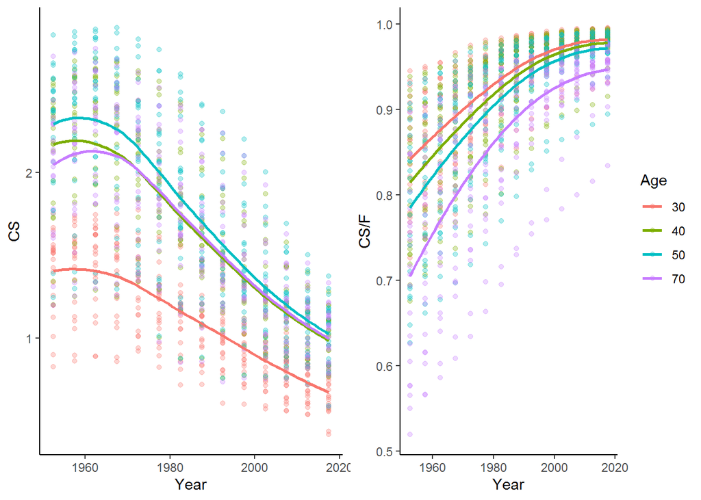

Child Survival and Child survival as a share of cummulative fertility by age, for women aged 30, 40 and 50. Estimates using UN WPP data for Latin American countries in the period 1950-2015 period

### An approximation of $CS_a$, the expected number of surviving daughters

As an initial step, we seek an intuitive understanding of the effect of changing mortality on child survival. Building on work by Keyfitz and Caswell (2005) for the probability of a living mother, we show which features of the child survival function explain the expected number of children. For this we use an approximate of $l_x$ using Taylor´s theorem until second order around the mean age of childbearing $\kappa$ for all $a>=\alpha$:

$$CS_a \approx l_{a-\kappa} \int_{\alpha}^a{m_{x}dx}+(l_{a-\kappa})^{'}\int_{0}^a{(x-\kappa)m_{x}dx}+
(l_{a-\kappa})^{''}\int_{0}^a{\frac{(x-\kappa)^2}{2} m_{x}dx}\\
\approx F_a l_{a-\kappa} + \frac{\sigma^2}{2}F_a (l_{a-\kappa})^{''}\\
\approx F_a \, l_{a-\kappa}[1+\frac{\sigma^2}{2}\frac{(l_{a-\kappa})^{''}}{l_{a-\kappa}}]$$

where the fertility pattern by age is concentrated around $\kappa$ and the accumulated fertility (or gross reproduction rate in our same-sex model) is $F_a = \int_{\alpha}^a{m_{x}dx}$. The second Taylor´s term is null because $\int_{\alpha}^a{x \, m_{x}dx} = \kappa \, F_a$.

We find that, seen from the perspective of a mother, child survival mainly depends on the cummulative fertility function[^2] and the mean age at childbearing $\kappa$ acts through the factor $l_{a-\kappa}$. The dispersion of of fertility $\sigma^2$ is negatively proportional to child survival. All else constant, a higher dispersion of fertility $\sigma^2$ is associated with a decrease in $CS_a$ during reproductive age. The negative relationship stems from the fact that the second derivative of $l_{a-\kappa}$ is negative in the 15-49 age range, given a concave downwards survival function.

Guatemala improved the approximation with years due to rectangularization process in $l_x$ (figure @ref(fig:plot_CS_aprox)).

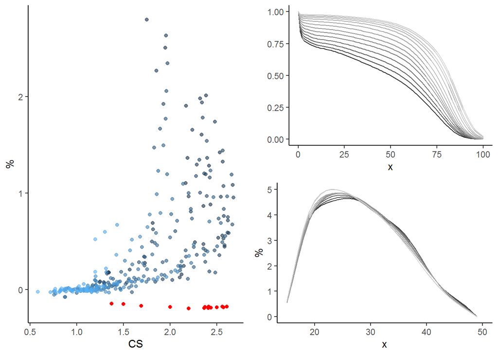

Left: Error in approximation for a=40, from years 1950 (darker) to 2015 (lighter) for all Latin American countries (blue) and Guatemala (red). Right: Change in survival and fertility by age in Guatemala.

### Burden and timing of maternal bereavement

We call *Mean Time Spent in Bereavement* (*MTSB*) the absolute measure of the expected total lifetime with a death daughter for a mother aged *a*, which can be expressed in terms of a temporary expected lost years index in line with $e^\dagger$ (Vaupel (1986)):

$$MTSB_a = \int_0^a{m_x\int_0^{a-x}{d_t e_{0|a-x-t}\, dt}\,dx} = \int_\alpha^a{m_x e_{0|a-x}^\dagger \,dx}$$
.

Where $d_t$ is the death distribution from birth, $e_{0|a-x-t}$ is the life expectancy at birth until age $a-x-t$ and $e_{0|a-x}^\dagger$ the temporary dispersion measure. But most interesting would be to compare these years with the time that mothers would expect to live with their daughters. We call this the *Intensity Time in Bereavement* ($ITB$)): a ratio between expected time with a “lost” and expected time with a “life”, that allows to make comparisons between population regimes.

$$ITL_a = \frac{\int_0^a{m_x e_{0|{a-x}}^\dagger dx}}{\int_0^a{m_x e_{0|a-x} dx}}$$

This is a ratio between child-years in two radically different states. Looks similar to the transcendental entropy measure $H$ (Keyfitz and Caswell (2005)) but considering all the cohorts born during the the mother´s life, weighted by their relative size $m_x$. In the figure @ref(fig:plot_ITL_MAL) is shown that *ITB* is bigger for young women because of the weight of infant mortality in their mother experience, also with more dispersion for same levels of parity. Assuming constant period rates the expected time in years that a mother aged 30 passed with a death son was around 4% in some countries at middle XX Century. When increasing age, the survival experience depends less on infant mortality, and the distribution is around less than 2% for women aged 50, converging to 0 on time. As extreme cases, in 1950-1955 Haiti women aged 30 would have experienced an intensity of 5.4%, and in 2010-2015 1.6%, while the women of Costa Rica 2.5%, and in 2010-2015 0.2%.

Another important factor for the child survival experience of mothers, is the mean age at child loss, called here $MAL$. This relation can be derived by starting with the mother age $x+t$ at each death child age $t$ at death, weighted by the fertility and survival function. In it, $\kappa$ is the mean age at childbirth for women aged $a$, $MAD_{a-x}$ refers to the mean age at death for newborns that die before $a-x$, $F_a$ is the accumulated fertility for a women aged $a$:

$$MAL_a = \frac{\int_0^a{m_x {\frac{\int_0^{a-x} l_t \, \mu_t (x+t) dt}{\int_0^{a-x} l_t \, \mu_t dt}}dx}}{\int_0^a{m_x}dx} \\
MAL_a = \frac{\int_0^a{m_x \left[{x+\frac{\int_0^{a-x} l_t \, \mu_t \, t \, dt}{\int_0^{a-x} l_t \, \mu_t dt}}\right]dx}}{\int_0^a{m_x}} \\
MAL_a = \frac{\int_0^a{m_x \,x \,dx}}{F_a} + \frac{\int_0^a{m_x MAD_{a-x}dx}}{F_a} \\
MAL_a = \kappa + \frac{\int_0^a{m_x MAD_{a-x}dx}}{F_a}$$

For those Latin American mothers aged 50 with 3 daughters born who suffered a lost, they experienced that at age 30 in average (figure @ref(fig:plot_ITL_MAL)) (More can be analyzed here).

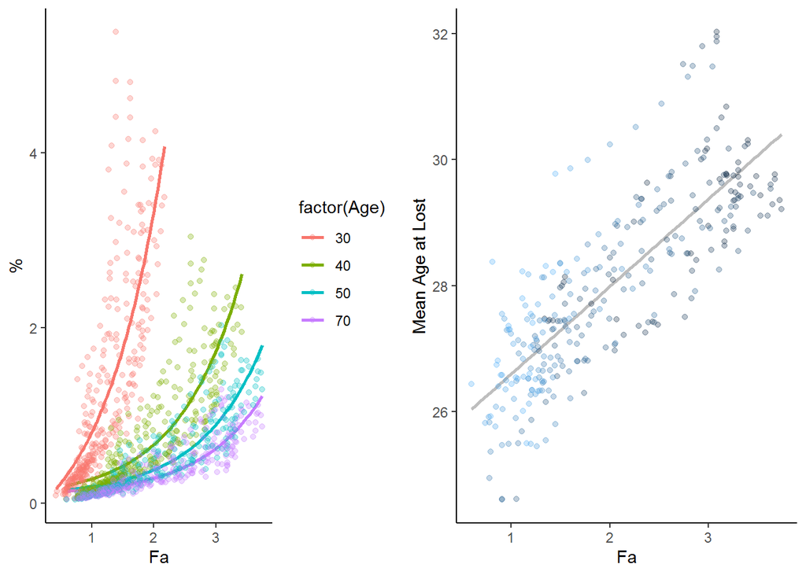

Intensity Tome Lost of womans aged 30, 40 and 50. Years 1950 (darker) to 2015 (lighter). Latinamerican countries in period 1950-2015

### Mortality changes

We now consider the consequences of an absolute change $\delta$ in mortality in the range $[0,a-\alpha]$, where $\alpha$ is the start age of fertility risk. As a corollary we consider the case where mortality only changes for infants, considering that it is unlikelily for a potential change in mortality to affect all ages equally in real populations. For now, let us consider $m_{x,\delta}=m_{x}+\delta$ (Wrycza and Baudisch (2012)) and $l_{a-x}^\delta = e^{-\int_{0}^{a-x}{(\mu_t+\delta})dt}$:

$$CS_{a}^\delta = \int_{\alpha}^{a}m_{x} l_{a-x} e^{-\delta (a-x)} dx$$

We get the derivative of $dCS_{(a)}^\delta / d\delta$ evaluated near zero (Keyfitz and Caswell (2005)) to find the effects of adding $\delta$ to hazard rates:

$$\frac{dCS^{\delta}}{d\delta} = -a\int_{\alpha}^{a}m_{x}{l_{a-x} dx} + \int_{\alpha}^{a} m_{x} {l_{a-x}x dx}\\
= -a \, CS_{a} + \int_{\alpha}^{a} {x \, m_{x} l_{a-x} dx}$$

Dividing both sides by $CS_{a}$ in an discrete approximation we get

$$\frac{\Delta CS_{a}}{CS_{a}} \approx -(a - k_a) \Delta\delta$$

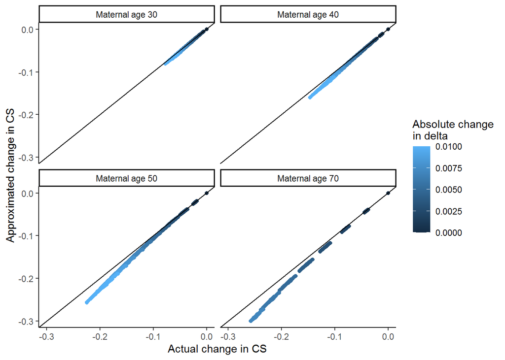

Effect of an absolute absolute change in mortality on child survival by maternal age of women in Latin America for the 1950-2015 period. Goodness of fit of approximation compared to direct estimation

We now consider the consequences of a proportional change in mortality on child survival. Given a proportional change in mortality $\mu_{x,\delta}=\mu_{x}(1+\delta)$ so that $l_{a-x}^\delta = e^{-\int_{0}^{a-x}{\mu_t(1+\delta})dt}=(l_{a-x})^{(1+\delta)}$, it follows that:

$$CS_{a}^\delta = \int_{\alpha}^{a} {m_{x} l_{a-x}^{(1+\delta)}} dx.$$

Using the derivative $\frac{dl_{a-x}^{(1+\delta)}}{d\delta} = log(l_{a-x}) l_{a-x}^{(1+\delta)}$, and in the third row reversing integrals between $t$ and $x$:

$$\frac{d CS_{a}^\delta}{d \delta} = \int_{\alpha}^{a} {m_{x} l_{a-x} \log(l_{a-x}) dx}\\
= - \int_{0}^{a} {m_{x} l_{a-x} \int_{0}^{a-x}{\mu_x \, dt}\, dx}\\
= - \int_{0}^{a}{\mu_t} \int_{0}^{a-t} {m_{x} l_{a-t-x} \, dx}\, dt$$

Dividing by $CS_a$ and multiplying by $\delta$ get one useful expression. This is the negative of cumulative hazard $H_a$ but considering a factor $0\leq \frac{CS_{a-t}}{CS_a}\leq1$ that takes in account the amount of surviving descendants that would be lost for a mother aged *a* in each age x of risk.

$$\frac{\Delta CS_{a}}{CS_a} = - \left[\int_{0}^{a}{\mu_t \, \frac{CS_{a-t}}{CS_a} \,dt \,}\right] \Delta \delta$$

Grasping this relationship intuitively is more difficult to given the interaction of birth and mortality rates (Keyfitz and Caswell (2005)). This factor has a S-shape because $l_x$ curvature fertility accumulation, that gives more weight to first ages, and which is grater than 1 only for ages *a* with complete reproductive life and high infant mortality (with no additional children and higher risk for one age additional of survive).

### Heterogeneity

In a model with heterogeneity, determined at birth with a multiplicative effect, $CS_a$ could be interpreted as a conditional expectation with random variables *K* for fertility heterogeneity and *Z* for mortality frailty.

$$CS_a(k,z) = \int_{0}^{\infty}\,{m(k)}_x\,{l(z)}_{a-x}\,dx$$

Following Coresh and Goldman (1988) we can express the fertility component in a multiplicative way with variability in the level but not in the shape, as ${m(k)}_x = F_\beta\,k\,r_x$, where $F_\beta$ is the baseline accumulated fertility, $K$ is a random variable with mean 1 that allows variability between groups and $r_x$ is the fertility structure by age ($\int_{0}^{\beta}{r_x}=1$). Frailty part can be thought in a cohort effect way, also in the multiplicative assumption as Vaupel and Missov (2014), with $l(z)_x=e^{-H_{x}Z}=l_x^Z$, with baseline hazard $\mu$. Replacing conveniently the last two expressions and considering the joint distribution $f_{kz}=f_{z/k} \,f_k$, the mean $\overline{CS}_a$ would be:

$$\overline{CS}_a = \int_{0}^{\infty}\int_{0}^{\infty}\left[\int_{0}^{a}{ {m(k)}_x l(z)_{a-x}\,dx}\right]f_{kz}\,dz \,dk\\
= F_\beta \int_{0}^{a-x} r_x \int_{0}^{\infty} \int_{0}^{\infty} {l_{a-x}}^z \, k\, f_{kz} \,dk\,dz\,dx$$

The way to chain dependence is convenient to the expected hierarchy $f_{zk}=f_{k|z}f_z$: groups with higher descendant´s mortality would adjust their fertility level, with positive correlation. Isolating one age and defining $f_{kz}$ we can explore effects in $CS_a$.

## Appendix

### Data

Mortality and fertility data was obtained from the last revision of population prospects by UN (Nations (2019)). We smoothed female $l_x$ using cubic-splines constrained to monotonic decrease, taking later $L_0$ and $T_{100}$ as inputs for year-person calculations. For splitting fertility five groups was used quadratic optimization approach by Michalski and Gorlishchev (2018), with an desirable property for our purpose which is a good fitting in parity. Also was assumed an unique female percentage of newborns of 0.49 for all period-country cases.

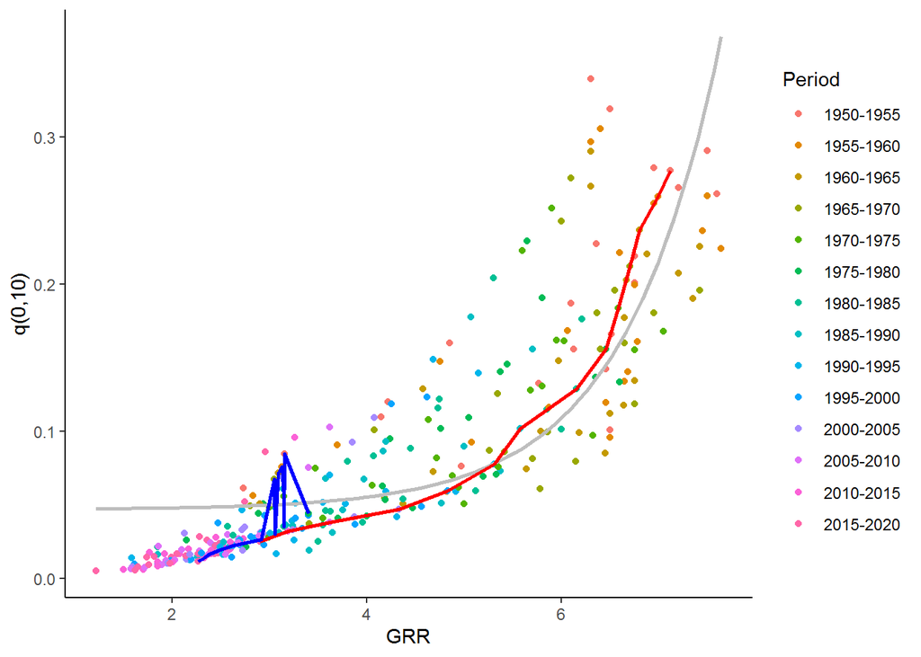

Female probability of death in first 10 years old by gross reproduction rate. Latin America countries in period 1950-2015

### Corollary

That an equal change in mortality could happens at all ages is unlikelihood. This measure is much more related to first ages (child and youth) than adult or ones. As a corollary, if the change only happens in the age range $\left[0;1\right)$, infant mortality, we can inspect the effect starting with splitting the integral (of course, for $a>1$)]:

$$CS_{a}^{\delta_0} = \int_{0}^{a-1}
m_{x} {e{^{-\int_{1}^{a-x}\mu_t \,dt-\int_{0}^{1}(\mu_t + \delta)\,dt}}} dx +
\int_{a-1}^{a} m_{x} e^{-\int_{0}^{a-x}(\mu_t+ \delta)\,dt}\\
=\int_{0}^{a-1} m_{x} l_{a-x}e^{-\delta} dx + \int_{a-1}^{a} m_{x} l_{a-x} e^{-\delta(a-x)}\,dx$$

Deriving by $\delta$ and valuating near 0, we get:

$$CS_{a}^{\delta_0} =-\int_{0}^{a-1} m_{x} l_{a-x} dx - a \int_{a-1}^{a} {m_{x} l_{a-x} dx} + \int_{a-1}^{a} {x \, m_{x} l_{a-x} dx}$$
If we name $CS_{a-1,a}=\int_{a-1}^{a} {m_{x} l_{a-x} dx}$, we can express the first term in the right as $CS_a - CS_{a-1,a}$, and finally divide by $CS_a$:
$$= - CS_a + CS_{a-1,a} (1-a+\kappa_{a-1,a})\\
\frac{\Delta CS_{a}}{CS_{a}} \approx - \left[1-\frac{CS_{a-1,a}}{CS_a} (1-(a-\kappa_{a-1,a}))\right] \Delta\delta$$

This means that an absolute change in infant hazard rate affects proportionally for all the age range extension (because of all the cohorts aged more than 1), except for the mean time exposure for those who born and survive in the last year $1-(a-k_{a-1,a})$, times $\frac{CS_{a-1,a}}{CS_a}$ the portion of cummulative alive daughters for the same period, weighting how important was this in total successful experience (in terms of alive descendants).

## References

Alburez-Gutierrez, Diego, Martin Kolk, and Emilio Zagheni. 2019. “Women’s Experience of Child Death over the Life Course: A Global Demographic Perspective.” Preprint. SocArXiv. https://doi.org/10.31235/osf.io/s69fz.

Bongaarts, John. 1987. “The Projection of Family Composition over the Life Course with Family Status Life Tables.” In *Family Demography: Methods and Their Application*, edited by John Bongaarts and Thomas Burch. Oxford: IUSSP Series, Oxford Univer- sity Pres.

Brass, W. 1953. “The Derivation of Fertility and Reproduction Rates from Restricted Data on Reproductive Histories.” *Population Studies* 7 (2): 137. https://doi.org/10.2307/2172029.

Coresh, Josef, and Noreen Goldman. 1988. “The effect of variability in the fertility schedule on numbers of kin.” *Math. Popul. Stud.* 1 (2): 137–56. https://doi.org/10.1080/08898488809525268.

Daatland, Svein Olav, Marijke Veenstra, and Ivar A. Lima. 2010. “Norwegian Sandwiches: On the Prevalence and Consequences of Family and Work Role Squeezes over the Life Course.” *European Journal of Ageing* 7 (4): 271–81. https://doi.org/10.1007/s10433-010-0163-3.

Goodman, Leo A, Nathan Keyfitz, and Thomas W Pullum. 1974. “Family Formation and the Frequency of Various Kinship Relationships.” *Theoretical Population Biology* 5 (1): 1–27.

Hendrickson, K. C. 2009. “Morbidity, Mortality, and Parental Grief: A Review of the Literature on the Relationship Between the Death of a Child and the Subsequent Health of Parents.” *Palliat Support Care* 7 (1): 109–19.

Keyfitz, Nathan, and Hal Caswell. 2005. *Applied Mathematical Demography*. Vol. 47. Springer.

Lee, Chioun, Dana A. Glei, Maxine Weinstein, and Noreen Goldman. 2014. “Death of a Child and Parental Wellbeing in Old Age: Evidence from Taiwan.” *Social Science & Medicine* 101 (January): 166–73. https://doi.org/10.1016/j.socscimed.2013.08.007.

Livi Bacci, Massimo. 1997. *A Concise History of World Population*. 2nd ed. Cambridge, MA: Blackwell.

Lotka, Alfred J. 1931. “Orphanhood in Relation to Demographic Factors.” *Metron* 9 (2): 37–109.

Michalski, Grigoriev, Anatoli I, and Vasily P and Gorlishchev. 2018. “R Programs for Splitting Abridged Fertility Data into a Fine Grid of Ages Using the Quadratic Optimization Method.” Max Planck Institute for Demographic Research, Rostock, Germany.

Nations, United. 2019. *World Population Prospects 2019: Data Booklet*. https://doi.org/https://doi.org/https://doi.org/10.18356/3e9d869f-en.

Preston, Samuel H, and others. 1978. *The Effects of Infant and Child Mortality on Fertility.* Academic Press, Inc., 111 Fifth Avenue, New York/New York 10003, USA.

Smith-Greenaway, Emily, and Jenny Trinitapoli. 2020. “Maternal Cumulative Prevalence Measures of Child Mortality Show Heavy Burden in Sub-Saharan Africa.” *Proceedings of the National Academy of Sciences*, February, 201907343. https://doi.org/10.1073/pnas.1907343117.

Vaupel, James W., and Trifon I. Missov. 2014. “Unobserved population heterogeneity: A review of formal relationships.” *Demographic Research* 31 (September): 659–86. https://www.demographic-research.org/Volumes/Vol31/22.

Vaupel, J. W. 1986. “How Change in Age-Specific Mortality Affects Life Expectancy.” *Population Studies* 40 (1): 147–57. https://doi.org/10.2307/2174285.

Volk, Anthony A., and Jeremy A. Atkinson. 2013. “Infant and Child Death in the Human Environment of Evolutionary Adaptation.” *Evolution and Human Behavior* 34 (3): 182–92. https://doi.org/10.1016/j.evolhumbehav.2012.11.007.

Wrycza, Tomasz, and Annette Baudisch. 2012. “How Life Expectancy Varies with Perturbations in Age-Specific Mortality.” *Demographic Research* 27: 365–76.

[^1]: We use woman and mother interchangeably in this paper, assuming that all women are exposed to the same fertility rates.
[^2]: Note that this runs contrary to the findings of Keyfitz and Caswell (2005), who found that levels of fertility did not affect the probability of having living ancestors.